## English

Grouping Countries Based on Students’ Opinion on Mathematics

□ Gathering The Data

□□ Based on Interest

We have considered the answers to these questions (questiones are writen directly from the questionnaire)

- I enjoy learning mathematics
- I wish I did not have to study mathematics
- Mathematics is boring
- I learn many interesting things in mathematics
- I like mathematics
- I like any schoolwork that involves numbers
- I like to solve mathematics problems
- I look forward to mathematics class
- Mathematics is one of my favorite subjects

Students gave a score ranging from 1 to 5 to each question, 1 meaning Disagree a lot, 5 meaning Agree a lot. Afterwards we calculated the average score for each individual country to the questions. For example, you can view the gathered data for 3 selected countries in this table:

| country | Enjoy Learning Math | Wish Did Not Have to Study Math | Math Is Boring | Learn Interesting Things in Math | Like Math | Like Numbers | Like Math Problems | Look Forward to Math Class | Math is Favorite Subject | score |
| --- | --- | --- | --- | --- | --- | --- | --- | --- | --- | --- |
| Canada | 2.036068 | 2.725954 | 2.582053 | 2.027268 | 2.154065 | 2.433565 | 2.351636 | 2.588250 | 2.514626 | 536.5824 |
| Chile | 2.218257 | 2.552048 | 2.457332 | 2.033402 | 2.346374 | 2.686113 | 2.568977 | 2.864333 | 2.805765 | 445.6053 |
| Egypt | 1.629663 | 2.819438 | 2.862684 | 1.593104 | 1.727151 | 1.822262 | 1.807252 | 1.915589 | 1.953634 | 406.8239 |

We performed the k-means algorithm on this data. The result of this algorithm can be seen in the biplot shown below:

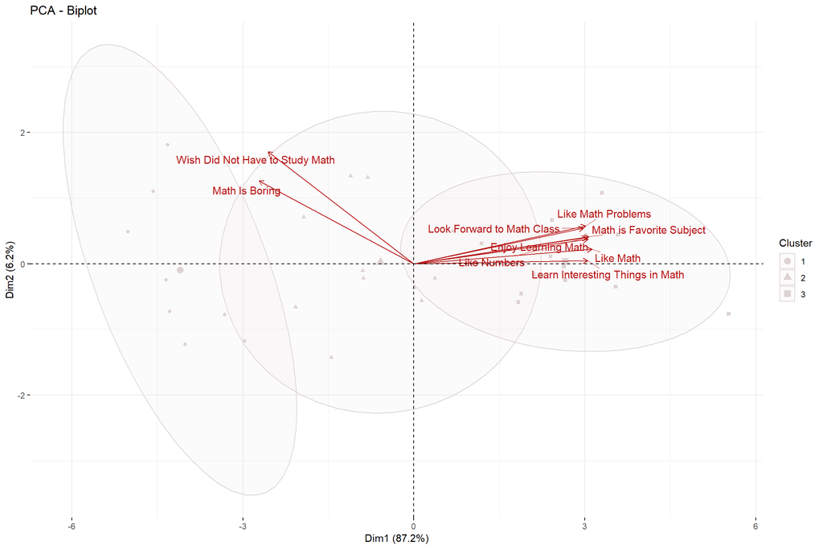

The correlation of the answers to each question with the top 5 principal components were as such:

[interactive chart not shown]

□□ Based on Talent

In this section and the one after, we have taken the same steps and the previous one. Therefor we refrain from repeting the descriptions.

We have considered the answers to these questions (questiones are writen directly from the questionnaire)

- I usually do well in mathematics
- Mathematics is more difficult for me than for many of my classmates
- Mathematics is not one of my strengths
- I learn things quickly in mathematics
- Mathematics makes me nervous
- I am good at working out difficult mathematics problems
- My teacher tells me I am good at mathematics
- Mathematics is harder for me than any other subject
- Mathematics makes me confused

biplot

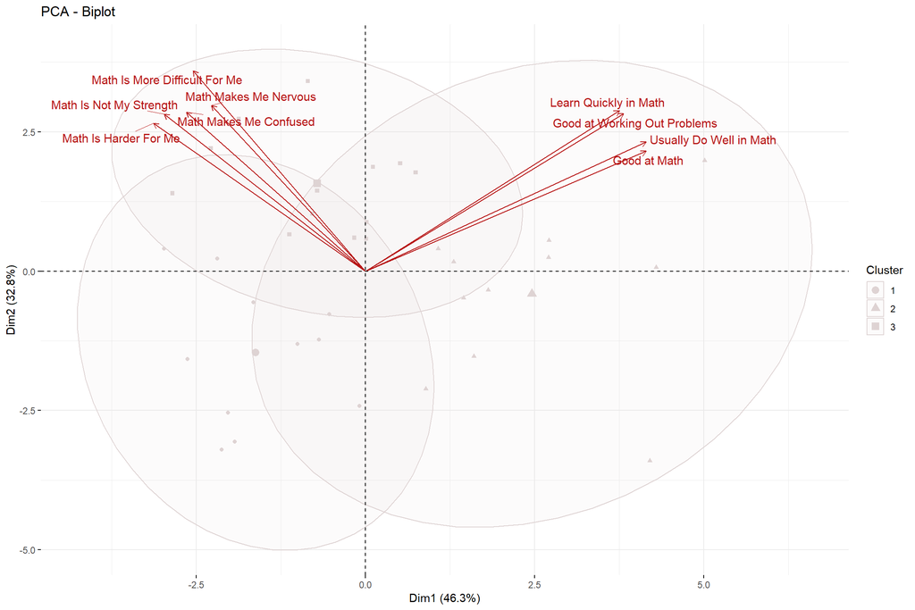

Correlation Matrix

[interactive chart not shown]

□□ Based on significance

We have considered the answers to these questions (questiones are writen directly from the questionnaire)

- I think learning mathematics will help me in my daily life
- I need mathematics to learn other school subjects
- I need to do well in mathematics to get into the of my choice
- I need to do well in mathematics to get the job I want
- I would like a job that involves using mathematics
- It is important to learn about mathematics to get ahead in the world
- Learning mathematics will give me more job opportunities when I am an adult
- My parents think that it is important that I do well in mathematics
- It is important to do well in mathematics

biplot

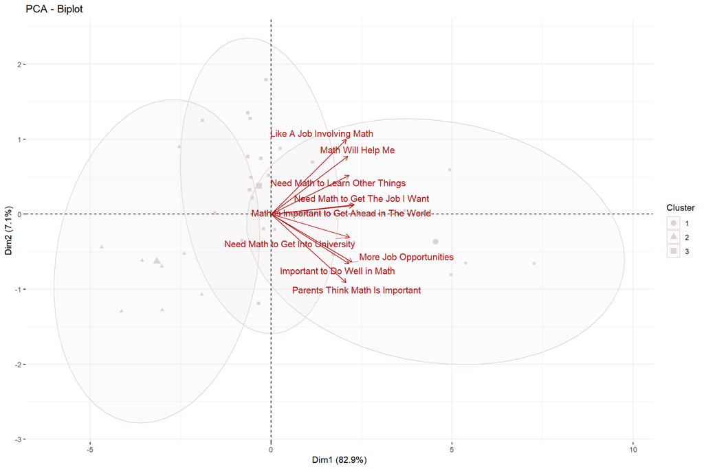

Correlation Matrix

[interactive chart not shown]

□ Performing Factor Analysis

In this section we have used the `psych` and `GPArotation` packages.

first we concatenate all the data used for the previous steps. Afterwards, using the `fa.parallel()` function we obtain the number of factors we need.

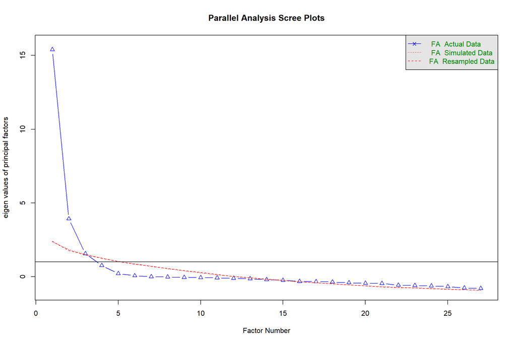

```
## Parallel analysis suggests that the number of factors =  3  and the number of components =  NA
```

According to the chart, 3 factors seem sufficient.

Next we much select a rotation model. For this data, we have selected the oblique model since based on the correlation matrices and the PCA charts displayed in the previous sections, it is clear that a few of the variables are correlated.

Also, based on the instructions given in R’s documentation:

> *fm = “minchi” will minimize the sample size weighted chi square when treating pairwise correlations with different number of subjects per pair.*

Finally, we run the algorithm.

Here, you can view a diagram of the factors.

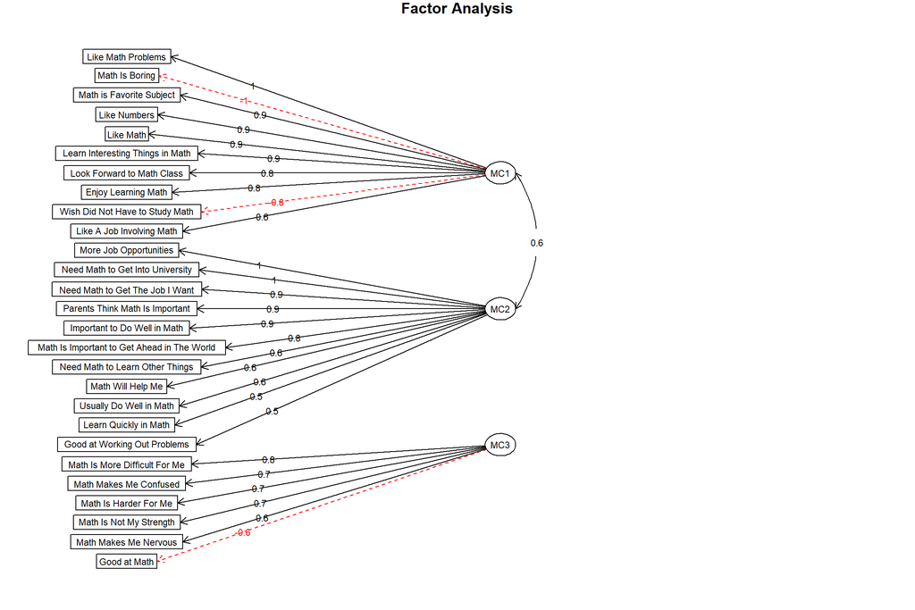

Here, you can view a diagram of the factors.

At last, below you can see the result of the algorithm.

```
## Factor Analysis using method =  minchi
## Call: fa(r = country.attitude %>% dplyr::select(-score, -country),
##     nfactors = 3, rotate = "oblimin", fm = "minchi")
## Standardized loadings (pattern matrix) based upon correlation matrix
##                                               MC1   MC2   MC3   h2    u2
## Enjoy Learning Math                          0.84  0.20  0.07 0.95 0.052
## Wish Did Not Have to Study Math             -0.80  0.07 -0.07 0.59 0.409
## Math Is Boring                              -0.97  0.26 -0.09 0.74 0.261
## Learn Interesting Things in Math             0.88  0.13  0.04 0.93 0.073
## Like Math                                    0.91  0.12  0.01 0.97 0.033
## Like Numbers                                 0.93  0.06 -0.04 0.94 0.062
## Like Math Problems                           0.97 -0.01 -0.09 0.93 0.073
## Look Forward to Math Class                   0.85  0.15  0.06 0.90 0.100
## Math is Favorite Subject                     0.94  0.04  0.03 0.94 0.056
## Math Will Help Me                            0.39  0.58 -0.02 0.76 0.238
## Need Math to Learn Other Things              0.36  0.64 -0.03 0.81 0.194
## Need Math to Get Into University            -0.02  0.99  0.12 0.91 0.088
## Need Math to Get The Job I Want              0.17  0.89  0.11 0.97 0.035
## Like A Job Involving Math                    0.65  0.44  0.05 0.94 0.059
## Math Is Important to Get Ahead in The World  0.22  0.77 -0.03 0.85 0.148
## More Job Opportunities                      -0.10  1.00 -0.01 0.89 0.107
## Parents Think Math Is Important             -0.07  0.88 -0.17 0.81 0.190
## Important to Do Well in Math                 0.05  0.87  0.05 0.79 0.207
## Usually Do Well in Math                      0.23  0.55 -0.48 0.84 0.164
## Math Is More Difficult For Me                0.48  0.03  0.78 0.90 0.097
## Math Is Not My Strength                      0.16 -0.05  0.70 0.53 0.469
## Learn Quickly in Math                        0.38  0.54 -0.35 0.85 0.146
## Math Makes Me Nervous                        0.01  0.16  0.59 0.33 0.667
## Good at Working Out Problems                 0.41  0.48 -0.41 0.85 0.148
## Good at Math                                 0.30  0.40 -0.57 0.79 0.205
## Math Is Harder For Me                        0.32 -0.16  0.71 0.65 0.346
## Math Makes Me Confused                      -0.24  0.37  0.74 0.50 0.503
##                                             com
## Enjoy Learning Math                         1.1
## Wish Did Not Have to Study Math             1.0
## Math Is Boring                              1.2
## Learn Interesting Things in Math            1.1
## Like Math                                   1.0
## Like Numbers                                1.0
## Like Math Problems                          1.0
```

[output cut: 40 more lines]

```
## The root mean square of the residuals (RMSR) is  0.06
## The df corrected root mean square of the residuals is  0.07
##
## The harmonic number of observations is  35 with the empirical chi square  87.68  with prob <  1
## The total number of observations was  35  with Likelihood Chi Square =  553.27  with prob <  3.4e-21
##
## Tucker Lewis Index of factoring reliability =  0.667
## RMSEA index =  0.249  and the 90 % confidence intervals are  0.153 NA
## BIC =  -417.34
## Fit based upon off diagonal values = 0.99
## Measures of factor score adequacy
##                                                   MC1 MC2  MC3
## Correlation of (regression) scores with factors     1   1 1.00
## Multiple R square of scores with factors            1   1 0.99
## Minimum correlation of possible factor scores       1   1 0.98
```

## Farsi

• دسته بندی کشورها براساس نظراتشان در رابطه با ریاضی

□ جمع آوری داده

□□ بر حسب علاقه

سوالات زیر را انتخاب کردیم:

- از یاد گرفتن ریاضیات لذت میبرم.
- آرزو میکنم کاش لازم نبود ریاضی یاد بگیرم
- ریاضی کسل کننده است
- من خیلی مسائل جالبی در ریاضی یاد میگیرم
- من ریاضی را دوست دارم
- من هرگونه مشق مرتبط با ریاضی را دوست دارم
- من حل مسائل ریاضی را دوست دارم
- من چشم انتظار کلاس های ریاضیم هستم
- ریاضی یکی از موضوعات موردعلاقه من است

| country | Enjoy Learning Math | Wish Did Not Have to Study Math | Math Is Boring | Learn Interesting Things in Math | Like Math | Like Numbers | Like Math Problems | Look Forward to Math Class | Math is Favorite Subject | score | cluster |
| --- | --- | --- | --- | --- | --- | --- | --- | --- | --- | --- | --- |
| Canada | 2.036068 | 2.725954 | 2.582053 | 2.027268 | 2.154065 | 2.433565 | 2.351636 | 2.588250 | 2.514626 | 536.5824 | 2 |
| Chile | 2.218257 | 2.552048 | 2.457332 | 2.033402 | 2.346374 | 2.686113 | 2.568977 | 2.864333 | 2.805765 | 445.6053 | 3 |
| Egypt | 1.629663 | 2.819438 | 2.862684 | 1.593104 | 1.727151 | 1.822262 | 1.807252 | 1.915589 | 1.953634 | 406.8239 | 1 |

سپس روی این داده الگوریتم k-means را اجرا کردیم. نتیجه ی این الگوریتم را بر روی نمودار biplot زیر مشاهده میفرمایید.

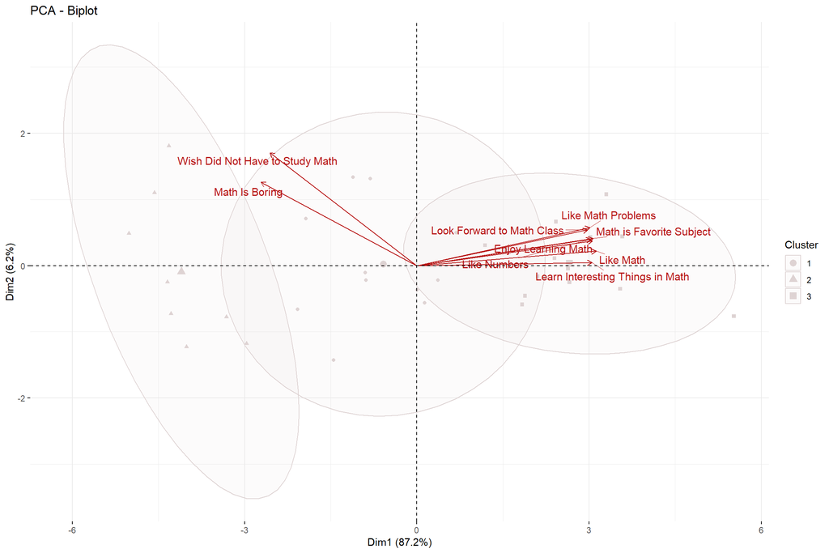

همچنین کورلیشن متغیرها را با مولفه های اصلی به دست آورده ایم:

[interactive chart not shown]

□□ بر حسب استعداد

در این قسمت و همچنین قسمت بعد، همانند قسمت قبلی عمل کرده ایم، پس از توضیحات اضافی پرهیز میکنیم.

در این قسمت سوالات زیر را بررسی کرده ایم:

- من معمولا در ریاضی خوب عمل میکنم
- ریاضی برای من نسبت به بقیه ی همکلاسی هایم سخت تر است
- ریاضی از نقات قوت من نیست
- من سریع مسائل را در ریاضی یاد میگیرم
- ریاضی باعث استرس من میشود
- من در حل مسائل دشوار ریاضی قوی عمل میکنم
- معلمم به من میگوید که من در ریاضی قوی هستم
- ریاضی برای من سخت تر از درس های دیگر است
- ریاضی باعث می شود من گیج بشوم

نمودار biplot

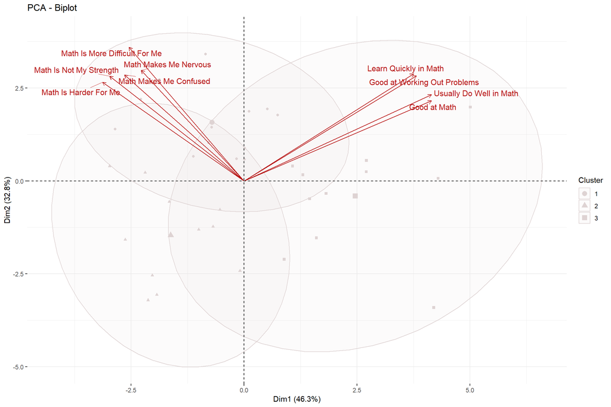

ماتریس کورلیشن ها

[interactive chart not shown]

□□ بر حسب اهمیت

در این قسمت سوالات زیر را بررسی کردیم:

- من فکر میکنم یادگیری ریاضی در زندگی روزمره به من کمک خواهد کرد
- من به ریاضی نیاز دارم تا درس های دیگر را یاد بگیرم
- من به ریاضی نیاز دارم تا بتوانم در دانشگاه مورد علاقه ام قبول شوم
- من به ریاضی نیاز دارم تا بتوانم به شغل مورد علاقه ام برسم
- من دوست دارم شغلی مرتبط با ریاضی داشته باشم
- یادگیری ریاضی برای پیشرفت در دنیا مهم است
- یادگیری ریاضی وقتی بزرگ بشوم برای من موقعیت های شغلی زیادی ایجاد خواهد کرد
- والدینم فکر میکنند که مهم است که من در ریاضی خوب عمل کنم
- قوی عمل کردن در ریاضی اهمیت دارد

نمودار biplot

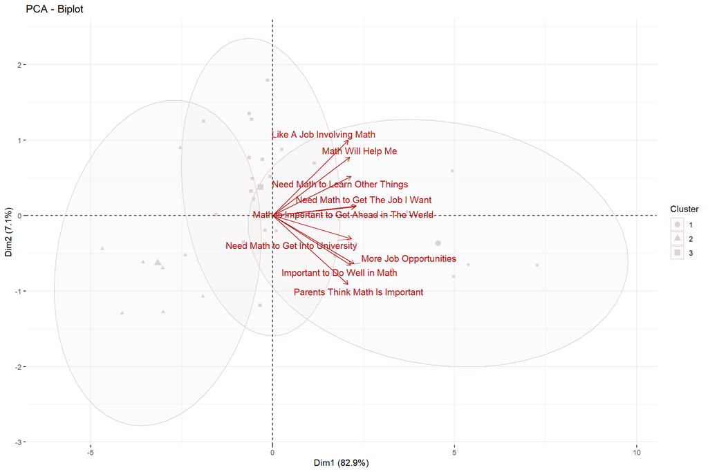

ماتریس کورلیشن ها

[interactive chart not shown]

□ پیاده سازی factor analysis بر روی داده

در این مرحله از پکیج های `psych` و `GPArotation` استفاده خواهیم کرد

ابتدا همه ی داده های سری قبل را به هم میچسبانیم. سپس با استفاده از تابع `fa.parallel()` بررسی میکنیم که چه تعداد فاکتور لازم است:

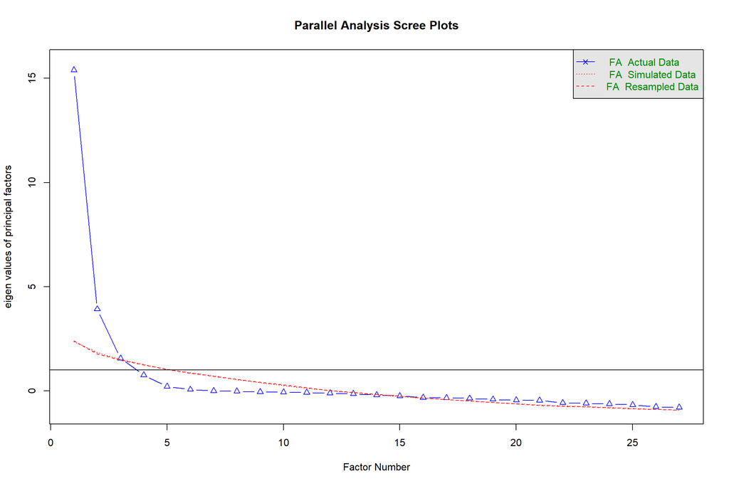

```
## Parallel analysis suggests that the number of factors =  3  and the number of components =  NA
```

با توجه به نتایج تابع میفهمیم ۳ فاکتور کافی است.

حال باید مدل rotation را انتخاب کنیم. برای این داده ها مدل oblique را انتخاب کرده ایم زیرا با توجه به ماتریس های کورلیشن و نمودارهای PCA که در قسمت های قبل کشیدیم، واضح است که بین یک سری از متغیرها کورلیشن موجود است.

همچنین بر حسب توضیحات r :

> fm = “minchi” will minimize the sample size weighted chi square when treating pairwise correlations with different number of subjects per pair.

مدل فاکتور کردن را از نوع minchi انتخاب کرده ایم.

حال الگوریتم را اجرا میکنیم.

دیاگرام فاکتور ها را رسم میکنیم:

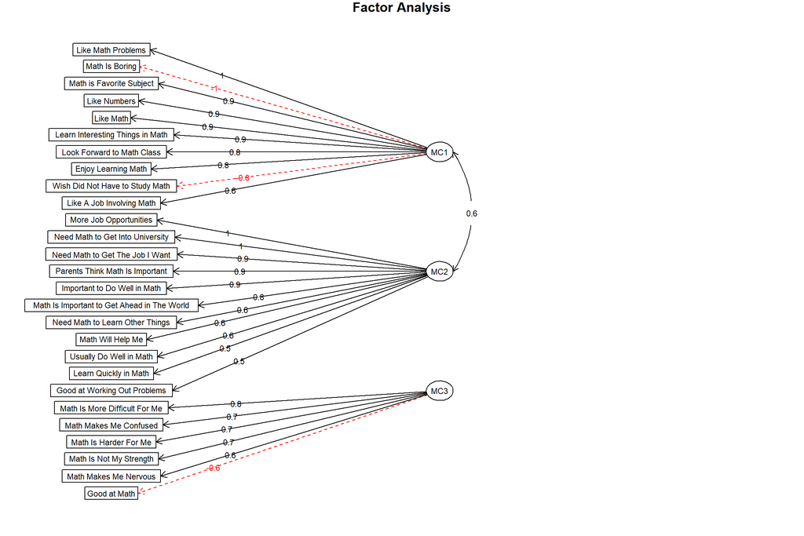

فاکتور ها به نظر میرسد که درست تعیین شده اند.

در نهایت نتیجه ی الگوریتم را نمایش میدهیم:

```
## Factor Analysis using method =  minchi
## Call: fa(r = country.attitude %>% dplyr::select(-score, -country),
##     nfactors = 3, rotate = "oblimin", fm = "minchi")
## Standardized loadings (pattern matrix) based upon correlation matrix
##                                               MC1   MC2   MC3   h2    u2
## Enjoy Learning Math                          0.84  0.20  0.07 0.95 0.052
## Wish Did Not Have to Study Math             -0.80  0.07 -0.07 0.59 0.409
## Math Is Boring                              -0.97  0.26 -0.09 0.74 0.261
## Learn Interesting Things in Math             0.88  0.13  0.04 0.93 0.073
## Like Math                                    0.91  0.12  0.01 0.97 0.033
## Like Numbers                                 0.93  0.06 -0.04 0.94 0.062
## Like Math Problems                           0.97 -0.01 -0.09 0.93 0.073
## Look Forward to Math Class                   0.85  0.15  0.06 0.90 0.100
## Math is Favorite Subject                     0.94  0.04  0.03 0.94 0.056
## Math Will Help Me                            0.39  0.58 -0.02 0.76 0.238
## Need Math to Learn Other Things              0.36  0.64 -0.03 0.81 0.194
## Need Math to Get Into University            -0.02  0.99  0.12 0.91 0.088
## Need Math to Get The Job I Want              0.17  0.89  0.11 0.97 0.035
## Like A Job Involving Math                    0.65  0.44  0.05 0.94 0.059
## Math Is Important to Get Ahead in The World  0.22  0.77 -0.03 0.85 0.148
## More Job Opportunities                      -0.10  1.00 -0.01 0.89 0.107
## Parents Think Math Is Important             -0.07  0.88 -0.17 0.81 0.190
## Important to Do Well in Math                 0.05  0.87  0.05 0.79 0.207
## Usually Do Well in Math                      0.23  0.55 -0.48 0.84 0.164
## Math Is More Difficult For Me                0.48  0.03  0.78 0.90 0.097
## Math Is Not My Strength                      0.16 -0.05  0.70 0.53 0.469
## Learn Quickly in Math                        0.38  0.54 -0.35 0.85 0.146
## Math Makes Me Nervous                        0.01  0.16  0.59 0.33 0.667
## Good at Working Out Problems                 0.41  0.48 -0.41 0.85 0.148
## Good at Math                                 0.30  0.40 -0.57 0.79 0.205
## Math Is Harder For Me                        0.32 -0.16  0.71 0.65 0.346
## Math Makes Me Confused                      -0.24  0.37  0.74 0.50 0.503
##                                             com
## Enjoy Learning Math                         1.1
## Wish Did Not Have to Study Math             1.0
## Math Is Boring                              1.2
## Learn Interesting Things in Math            1.1
## Like Math                                   1.0
## Like Numbers                                1.0
## Like Math Problems                          1.0
```

[output cut: 40 more lines]

```
## The root mean square of the residuals (RMSR) is  0.06
## The df corrected root mean square of the residuals is  0.07
##
## The harmonic number of observations is  35 with the empirical chi square  87.68  with prob <  1
## The total number of observations was  35  with Likelihood Chi Square =  553.27  with prob <  3.4e-21
##
## Tucker Lewis Index of factoring reliability =  0.667
## RMSEA index =  0.249  and the 90 % confidence intervals are  0.153 NA
## BIC =  -417.34
## Fit based upon off diagonal values = 0.99
## Measures of factor score adequacy
##                                                   MC1 MC2  MC3
## Correlation of (regression) scores with factors     1   1 1.00
## Multiple R square of scores with factors            1   1 0.99
## Minimum correlation of possible factor scores       1   1 0.98
```